# Titanic

Nicole Wittlin, Cho Kim, Jonathan Marin

April 4, 2018

# Kaggle Titanic Competition

https://www.kaggle.com/c/titanic/data

# Introduction

The sinking of the RMS Titanic is one of the most infamous shipwrecks in history. On April 15, 1912, during her maiden voyage, the Titanic sank after colliding with an iceberg, killing 1502 out of 2224 passengers and crew. This sensational tragedy shocked the international community and led to better safety regulations for ships.

One of the reasons that the shipwreck led to such loss of life was that there were not enough lifeboats for the passengers and crew. Although there was some element of luck involved in surviving the sinking, some groups of people were more likely to survive than others, such as women, children, and the upper-class.

In this kaggle challenge, we must complete the analysis of what sorts of people were likely to survive. In particular, we need to apply the tools of machine learning to predict which passengers survived the tragedy.

# Packages

```r
#library(xlsx)
library(knitr)
library(ggplot2)
library(sqldf)
library(reshape2)
library(magrittr)
library(kableExtra)
library(doBy)
library(caret)
library(parallel)
library(doParallel)
library(randomForest)
```

# Data Dictionary

```r
#variables <- read.xlsx("Variables.xlsx", "Sheet1")
variables <- read.csv("Variables.csv", sep=",")


kable((variables), "html") %>% kable_styling(bootstrap_options="striped", full_width = F, font_size = 12)
```

| Variable | Definition | Key |
| --- | --- | --- |
| survival | Survival | 0 = No, 1 = Yes |
| pclass | Ticket class | 1 = 1st, 2 = 2nd, 3 = 3rd |
| sex | Sex |  |
| Age | Age in years |  |
| sibsp | # of siblings / spouses aboard the Titanic |  |
| parch | # of parents / children aboard the Titanic |  |
| ticket | Ticket number |  |
| fare | Passenger fare |  |
| cabin | Cabin number |  |
| embarked | Port of Embarkation | C = Cherbourg, Q = Queenstown, S = Southampton |

# Variable Notes

Variable Notes pclass: A proxy for socio-economic status (SES) 1st = Upper 2nd = Middle 3rd = Lower

age: Age is fractional if less than 1. If the age is estimated, is it in the form of xx.5

sibsp: The dataset defines family relations in this way… Sibling = brother, sister, stepbrother, stepsister Spouse = husband, wife (mistresses and fiancés were ignored)

parch: The dataset defines family relations in this way… Parent = mother, father Child = daughter, son, stepdaughter, stepson Some children travelled only with a nanny, therefore parch=0 for them.

# Import the Data

We have two train and test sets. One to try imputaing age, and the other to get it from the web(source: Encyclopedia-Titanica). We would like to see the difference.

```r
##setwd("C:/Users/i64756/Desktop/Kaggle/Titanic")


train <- read.csv("train.csv")

#Adding a column to train to indicate that it is the train set

train$Set <- "train"

test <- read.csv("test.csv")

test$Set <- "test"

#We have two train and test sets.  One to try imputaing age, and the other to get it from the web.
#We would like to see the difference.

# age added for data with blanks from encylopedia-titanica.
train_age <- read.csv("trainage.csv", sep=",")
train_age$Set <- "train"

test_age <- read.csv("testage.csv", sep = ",")
test_age$Set <- "test"
```

# Exploratory Analysis

## Women and Children First

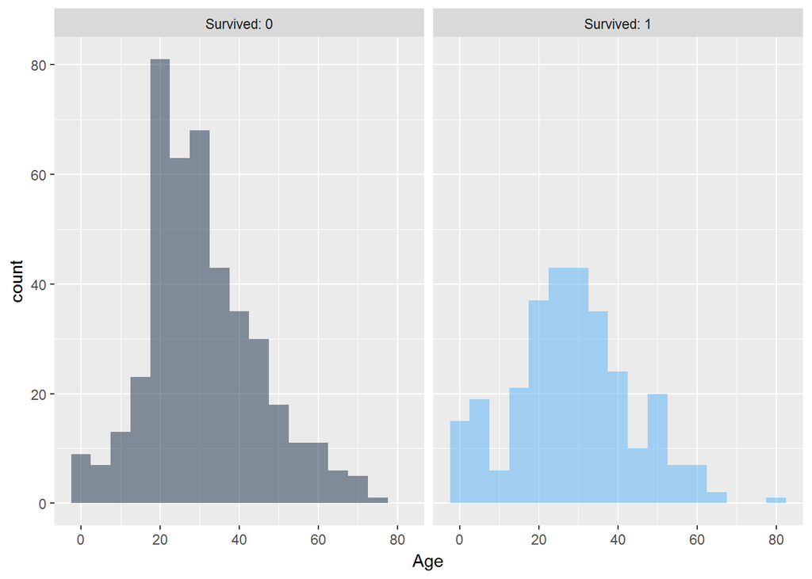

```r
ggplot(train, aes(x=Age, group = Survived, fill = Survived)) +
    geom_histogram(binwidth=5, alpha=.5, position="identity")+   facet_grid(~Survived, labeller = label_both) + theme(legend.position="none")
```

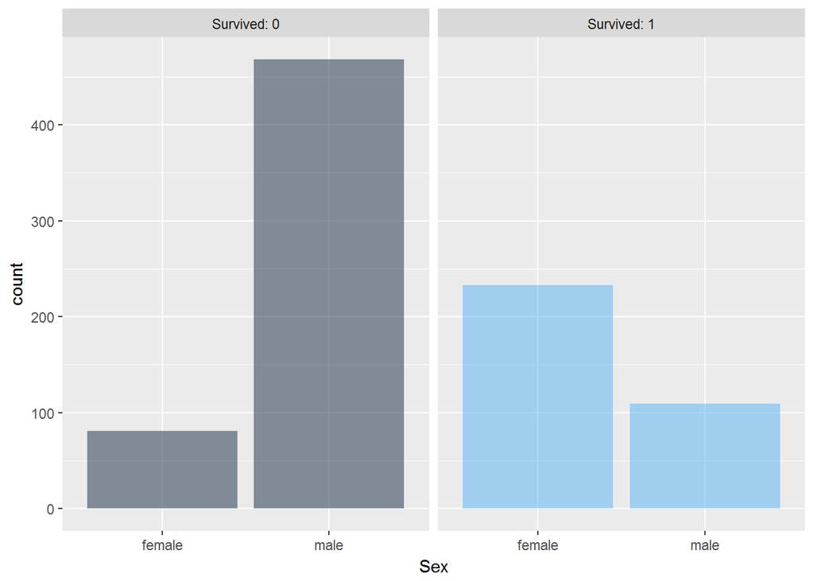

```r
ggplot(train, aes(x=Sex, group = Survived, fill = Survived)) +
    geom_histogram(stat = "count", binwidth=5, alpha=.5, position="identity")+   facet_grid(~Survived, labeller = label_both) + theme(legend.position="none")
```

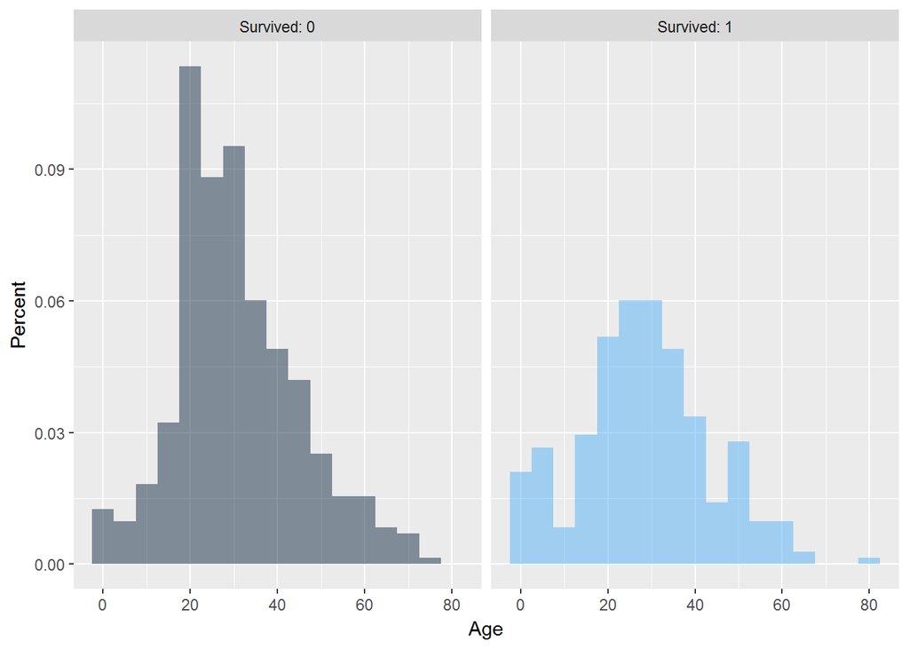

```r
ggplot(train, aes(x=Age, group = Survived, fill = Survived)) +
    geom_histogram(aes(y=(..count..)/sum(..count..)),binwidth=5, alpha=.5, position="identity")+   facet_grid(~Survived, labeller = label_both) + theme(legend.position="none") +
  ylab("Percent")
```

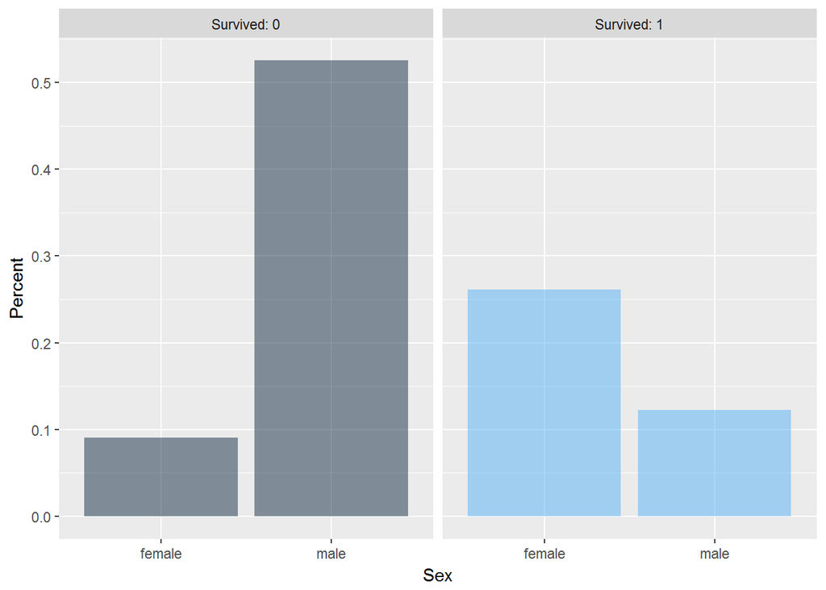

```r
ggplot(train, aes(x=Sex, group = Survived, fill = Survived)) +
    geom_histogram(stat = "count", aes(y=(..count..)/sum(..count..)),binwidth=5, alpha=.5, position="identity")+   facet_grid(~Survived, labeller = label_both) + theme(legend.position="none") +
  ylab("Percent")
```

# Clean and Prep the Data

```r
#We want to add the Survived variable to the test set so that we can combine training and test

test$Survived <- NA

test_age$Survived <- NA


#Combining the train and test set so that we can clean the data for both sets
combined <- rbind(train,test)

combined_age <- rbind(train_age,test_age)

#Testing to see what class these features are

class(combined$PassengerId)
```

```
## [1] "integer"
```

```r
class(combined$Survived)
```

```
## [1] "integer"
```

```r
class(combined$Pclass)
```

```
## [1] "integer"
```

```r
class(combined$Name)
```

```
## [1] "factor"
```

```r
class(combined$Sex)
```

```
## [1] "factor"
```

```r
class(combined$Age)
```

```
## [1] "numeric"
```

```r
class(combined$SibSp)
```

```
## [1] "integer"
```

```r
class(combined$Parch)
```

```
## [1] "integer"
```

```r
class(combined$Ticket)
```

```
## [1] "factor"
```

```r
class(combined$Fare)
```

```
## [1] "numeric"
```

```r
class(combined$Embarked)
```

```
## [1] "factor"
```

```r
#I don't see any issues with the classes for the features
```

# Missing Variable Values

We need to see what values are missing and what to do with them. With little data, we shouldn’t exclude if we can. Possibly we can impute them.

```r
sapply(combined, function(x) sum(is.na(x)))
```

```
## PassengerId    Survived      Pclass        Name         Sex         Age
##           0         418           0           0           0         263
##       SibSp       Parch      Ticket        Fare       Cabin    Embarked
##           0           0           0           1           0           0
##         Set
##           0
```

```r
#The 418 surived variables make sense because we have the test set here.  However, the age is missing quite a bit.  Probably need to come up with a way to fill in the age by imputing.



# Found a source that had ages
sapply(combined_age, function(x) sum(is.na(x)))
```

```
## PassengerId    Survived      Pclass        Name         Sex         Age
##           0         418           0           0           0          10
##       SibSp       Parch      Ticket        Fare       Cabin    Embarked
##           0           0           0           1           0           0
##         Set
##           0
```

# Feature Engineering

```r
#Want to create a variable by title.  This might help predict age.

combined$Title <- gsub( "^.*, ", '' , combined$Name)
combined$Title <- gsub(" .*" , '', combined$Title)

combined_age$Title <- gsub( "^.*, ", '' , combined$Name)
combined_age$Title <- gsub(" .*" , '', combined$Title)
```

# Imputing Age

There are many ways to impute age and this is obviously an important variable to the model for two possible reasons:

1. We know that Women and Children were allowed on life boats first
2. Age is a factor in determing a person’s health once on a boat which is crucial for survival.

That being said, would it make sense to group age into smaller categories because being 22 vs being 23 might not be significant. However, being an infant vs toddler vs teenager vs senior citizen might be.

First, let’s make a new variable for age to categorize.

```r
FilledAges <- sqldf("SELECT * FROM combined where Age is not null")

MissingAgesTitle <- sqldf("SELECT Title, count(*) as 'Count' FROM combined where Age is null group by Title")

MissingAgesTitle
```

```
##     Title Count
## 1     Dr.     1
## 2 Master.     8
## 3   Miss.    50
## 4     Mr.   176
## 5    Mrs.    27
## 6     Ms.     1
```

```r
summaryBy(Age ~ Title, data = FilledAges, FUN =  list(mean, max,min, median, sd))
```

```
##        Title  Age.mean Age.max Age.min Age.median    Age.sd
## 1      Capt. 70.000000    70.0   70.00       70.0        NA
## 2       Col. 54.000000    60.0   47.00       54.5  5.477226
## 3       Don. 40.000000    40.0   40.00       40.0        NA
## 4      Dona. 39.000000    39.0   39.00       39.0        NA
## 5        Dr. 43.571429    54.0   23.00       49.0 11.731115
## 6  Jonkheer. 38.000000    38.0   38.00       38.0        NA
## 7      Lady. 48.000000    48.0   48.00       48.0        NA
## 8     Major. 48.500000    52.0   45.00       48.5  4.949747
## 9    Master.  5.482642    14.5    0.33        4.0  4.161554
## 10     Miss. 21.774238    63.0    0.17       22.0 12.249077
## 11     Mlle. 24.000000    24.0   24.00       24.0  0.000000
## 12      Mme. 24.000000    24.0   24.00       24.0        NA
## 13       Mr. 32.252151    80.0   11.00       29.0 12.422089
## 14      Mrs. 36.994118    76.0   14.00       35.5 12.901767
## 15       Ms. 28.000000    28.0   28.00       28.0        NA
## 16      Rev. 41.250000    57.0   27.00       41.5 12.020815
## 17      Sir. 49.000000    49.0   49.00       49.0        NA
## 18       the 33.000000    33.0   33.00       33.0        NA
```

```r
#Imputed Age: Using the medians of Age per title

combined <- sqldf("select a.*,  case
  when Age is null and Title = 'Capt.' then 70
  when Age is null and Title = 'Col.' then 54
  when Age is null and Title = 'Don.' then 40
  when Age is null and Title = 'Dona.' then 39
  when Age is null and Title = 'Dr.' then 49
  when Age is null and Title = 'Lady' then 48
  when Age is null and Title = 'Major.' then 48
  when Age is null and Title = 'Master.' then 4
  when Age is null and Title = 'Miss.' then 22
  when Age is null and Title = 'Mlle.' then 24
  when Age is null and Title = 'Mme.' then 24
  when Age is null and Title = 'Mr.' then 29
  when Age is null and Title = 'Mrs.' then 40
  when Age is null and Title = 'Ms.' then 28
  when Age is null and Title = 'Rev.' then 42
  when Age is null and Title = 'Sir.' then 49
  else Age end as 'ImputedAge' from combined a")


combined_age <- sqldf("select a.*,  case
  when Age is null and Title = 'Capt.' then 70
  when Age is null and Title = 'Col.' then 54
  when Age is null and Title = 'Don.' then 40
  when Age is null and Title = 'Dona.' then 39
  when Age is null and Title = 'Dr.' then 49
  when Age is null and Title = 'Lady' then 48
  when Age is null and Title = 'Major.' then 48
  when Age is null and Title = 'Master.' then 4
  when Age is null and Title = 'Miss.' then 22
  when Age is null and Title = 'Mlle.' then 24
  when Age is null and Title = 'Mme.' then 24
  when Age is null and Title = 'Mr.' then 29
  when Age is null and Title = 'Mrs.' then 40
  when Age is null and Title = 'Ms.' then 28
  when Age is null and Title = 'Rev.' then 42
  when Age is null and Title = 'Sir.' then 49
  else Age end as 'ImputedAge' from combined_age a")

#Check to make sure all ages were imputed
sapply(combined, function(x) sum(is.na(x)))
```

```
## PassengerId    Survived      Pclass        Name         Sex         Age
##           0         418           0           0           0         263
##       SibSp       Parch      Ticket        Fare       Cabin    Embarked
##           0           0           0           1           0           0
##         Set       Title  ImputedAge
##           0           0           0
```

```r
sapply(combined_age, function(x) sum(is.na(x)))
```

```
## PassengerId    Survived      Pclass        Name         Sex         Age
##           0         418           0           0           0          10
##       SibSp       Parch      Ticket        Fare       Cabin    Embarked
##           0           0           0           1           0           0
##         Set       Title  ImputedAge
##           0           0           0
```

# Creating Age Classes

```r
combined <- sqldf("SELECT a.*, CASE WHEN ImputedAge is Null then NULL when ImputedAge <= 2 then 'Infant' when ImputedAge <= 5 then 'Toddler' when ImputedAge <= 12 then 'Child' when ImputedAge <= 18 then 'Teen' when ImputedAge <= 30 then 'Adult' when ImputedAge <= 40 then 'OlderAdult' when ImputedAge <= 65 then 'OvertheHill' else 'Senior' end as 'AgeClass' from combined a")

combined_age <- sqldf("SELECT a.*, CASE WHEN ImputedAge is Null then NULL when ImputedAge <= 2 then 'Infant' when ImputedAge <= 5 then 'Toddler' when ImputedAge <= 12 then 'Child' when ImputedAge <= 18 then 'Teen' when ImputedAge <= 30 then 'Adult' when ImputedAge <= 40 then 'OlderAdult' when ImputedAge <= 65 then 'OvertheHill' else 'Senior' end as 'AgeClass' from combined_age a")




#Check to make sure that I categorized all passengers
sapply(combined, function(x) sum(is.na(x)))
```

```
## PassengerId    Survived      Pclass        Name         Sex         Age
##           0         418           0           0           0         263
##       SibSp       Parch      Ticket        Fare       Cabin    Embarked
##           0           0           0           1           0           0
##         Set       Title  ImputedAge    AgeClass
##           0           0           0           0
```

# Combine Rare Titles

After running a model with the titles created as is, there was an issue where the test set had a title that the train set did not. Will need to combine the rare titles.

```r
sqldf("Select Title, Count(Title) as 'Count' from combined group by Title order by count(Title)")
```

```
##        Title Count
## 1      Capt.     1
## 2       Don.     1
## 3      Dona.     1
## 4  Jonkheer.     1
## 5      Lady.     1
## 6       Mme.     1
## 7       Sir.     1
## 8        the     1
## 9     Major.     2
## 10     Mlle.     2
## 11       Ms.     2
## 12      Col.     4
## 13       Dr.     8
## 14      Rev.     8
## 15   Master.    61
## 16      Mrs.   197
## 17     Miss.   260
## 18       Mr.   757
```

```r
#All the rarer titles seem to be of rank or nobility, will combine these



combined <- sqldf(c("update combined set Title = 'Nobility' where Title in
('Capt.',
'Col.',
'Don.',
'Dona.',
'Jonkheer.',
'Lady.',
'Major.',
'Mlle.',
'Mme.',
'Ms.',
'Sir.',
'the')","select * from combined"))

combined_age <- sqldf(c("update combined set Title = 'Nobility' where Title in
('Capt.',
'Col.',
'Don.',
'Dona.',
'Jonkheer.',
'Lady.',
'Major.',
'Mlle.',
'Mme.',
'Ms.',
'Sir.',
'the')","select * from combined_age"))
```

# Seperate Train and Test for Variables we want

```r
train2 <- sqldf("select Pclass, Sex, SibSP, Parch, Title, AgeClass, Survived
                from combined a
                Where [Set] = 'train'")

test2 <- sqldf("select Pclass, Sex, SibSP, Parch, Title, AgeClass
                from combined a
                Where [Set] = 'test'")

train2_age <- sqldf("select Pclass, Sex, SibSP, Parch, Title, AgeClass, Survived
                from combined_age a
                Where [Set] = 'train'")

test2_age <- sqldf("select Pclass, Sex, SibSP, Parch, Title, AgeClass
                from combined_age a
                Where [Set] = 'test'")
```

# Model

```r
#Adding more cores to R/model for faster processing and leaving 1 for OS
cluster <- makeCluster(detectCores() - 1)
registerDoParallel(cluster)

train2$Survived <- as.factor(train2$Survived)

train2_age$Survived <- as.factor(train2_age$Survived)

fitControl <- trainControl(method = "cv",
                           number = 2,
                           allowParallel = TRUE)



#Random Forest

#Comparing imputed age vs actual age

RFfitAge <- train(Survived ~., data = train2_age, method = "rf", trControl = fitControl)

RFfitAge$finalModel
```

```
##
## Call:
##  randomForest(x = x, y = y, mtry = param$mtry)
##                Type of random forest: classification
##                      Number of trees: 500
## No. of variables tried at each split: 2
##
##         OOB estimate of  error rate: 18.86%
## Confusion matrix:
##     0   1 class.error
## 0 476  73   0.1329690
## 1  95 247   0.2777778
```

```r
print(RFfitAge)
```

```
## Random Forest
##
## 891 samples
##   6 predictor
##   2 classes: '0', '1'
##
## No pre-processing
## Resampling: Cross-Validated (2 fold)
## Summary of sample sizes: 445, 446
## Resampling results across tuning parameters:
##
##   mtry  Accuracy   Kappa
##    2    0.8103668  0.5917644
##   14    0.8002444  0.5722246
##   27    0.7822794  0.5309257
##
## Accuracy was used to select the optimal model using the largest value.
## The final value used for the model was mtry = 2.
```

```r
RFfit <- train(Survived ~., data = train2, method = "rf", trControl = fitControl)

RFfit$finalModel
```

```
##
## Call:
##  randomForest(x = x, y = y, mtry = param$mtry)
##                Type of random forest: classification
##                      Number of trees: 500
## No. of variables tried at each split: 2
##
##         OOB estimate of  error rate: 19.08%
## Confusion matrix:
##     0   1 class.error
## 0 472  77   0.1402550
## 1  93 249   0.2719298
```

```r
print(RFfit)
```

```
## Random Forest
##
## 891 samples
##   6 predictor
##   2 classes: '0', '1'
##
## No pre-processing
## Resampling: Cross-Validated (2 fold)
## Summary of sample sizes: 446, 445
## Resampling results across tuning parameters:
##
##   mtry  Accuracy   Kappa
##    2    0.8215473  0.6178813
##    9    0.8024714  0.5671234
##   17    0.7867486  0.5373908
##
## Accuracy was used to select the optimal model using the largest value.
## The final value used for the model was mtry = 2.
```

```r
#Gradient Boosting Machine)

modFit <- train(Survived ~., method = "gbm", data=train2, verbose = FALSE)

modFit
```

```
## Stochastic Gradient Boosting
##
## 891 samples
##   6 predictor
##   2 classes: '0', '1'
##
## No pre-processing
## Resampling: Bootstrapped (25 reps)
## Summary of sample sizes: 891, 891, 891, 891, 891, 891, ...
## Resampling results across tuning parameters:
##
##   interaction.depth  n.trees  Accuracy   Kappa
##   1                   50      0.8066385  0.5881131
##   1                  100      0.8150542  0.6066771
##   1                  150      0.8166582  0.6095193
##   2                   50      0.8151664  0.6037272
##   2                  100      0.8184974  0.6112997
##   2                  150      0.8149300  0.6025250
##   3                   50      0.8167150  0.6069295
##   3                  100      0.8151737  0.6016734
##   3                  150      0.8140999  0.5997625
##
## Tuning parameter 'shrinkage' was held constant at a value of 0.1
##
## Tuning parameter 'n.minobsinnode' was held constant at a value of 10
## Accuracy was used to select the optimal model using the largest value.
## The final values used for the model were n.trees = 100,
##  interaction.depth = 2, shrinkage = 0.1 and n.minobsinnode = 10.
```

```r
#Predict the test set with the best model
#using modfit here

pred <- predict(RFfit, newdata = test2)

pred
```

```
##   [1] 0 1 0 0 1 0 1 0 1 0 0 0 1 0 1 1 0 0 1 1 0 1 1 0 1 0 1 0 0 0 0 0 1 1 0
##  [36] 0 1 1 0 0 0 0 0 1 1 0 0 0 1 1 0 0 1 1 0 0 0 0 0 1 0 0 0 1 1 1 1 0 0 1
##  [71] 1 0 1 0 1 0 0 1 0 1 0 0 0 0 0 0 1 1 1 1 1 0 1 0 0 0 1 0 1 0 1 0 0 0 1
## [106] 0 0 0 0 0 0 1 1 1 1 0 0 1 0 1 1 0 1 0 0 1 0 1 0 0 0 0 1 0 0 0 0 0 1 0
## [141] 0 1 0 0 0 0 0 0 0 0 1 0 0 1 0 0 1 1 0 1 1 0 1 0 0 1 0 0 1 1 0 0 0 0 0
## [176] 1 1 0 1 1 0 0 1 0 1 0 1 0 0 0 0 0 0 0 1 0 1 1 0 1 1 1 1 1 0 0 1 0 1 0
## [211] 0 0 0 1 1 0 1 0 1 0 1 0 1 0 1 1 0 1 0 0 0 1 0 0 0 0 0 0 1 1 1 1 0 0 1
## [246] 0 1 0 1 1 1 0 0 0 0 0 0 0 1 0 0 0 1 1 0 0 0 0 1 0 0 0 1 1 0 1 0 0 0 0
## [281] 1 1 1 1 1 0 0 0 0 0 0 1 0 0 0 0 1 0 0 0 0 0 0 0 1 1 0 1 0 1 0 0 0 1 1
## [316] 1 0 0 0 0 0 0 0 0 1 0 1 0 0 0 1 0 0 1 0 0 0 0 0 1 0 0 0 1 1 1 0 1 0 1
## [351] 1 0 0 0 1 0 1 0 0 1 0 1 1 0 1 1 0 1 1 0 0 1 0 0 1 1 1 0 0 0 0 0 1 1 0
## [386] 1 0 0 0 0 0 1 0 0 0 1 0 1 0 0 1 0 1 0 0 0 0 0 1 1 1 1 1 0 1 0 0 1
## Levels: 0 1
```

```r
submission <- as.data.frame(cbind(test$PassengerId, as.character(pred)))

names(submission) <- c("PassengerId","Survived")


write.csv(submission, file = "kagglescorerf.csv", row.names = FALSE)
```